# Observational Data – Management Outcomes

7. Once we test the relationship of trt on invaders, we’ll next want to ask what the relationship of trt on natives is –through the invaders. In order to do this, I imagined an instrumental variable approach. BUT it doesn’t seem like we have a decent instrument (if treatment doesn’t reliably change the abundance of the invader, then there’s no reason to believe it could change the invader abund enough to drive subsequent changes in the native community ). As such, we’re just going to do something similar to the invader control matching work, but now asking if native diversity shows a treatment effect.

For EWM this is pretty straighforward, the timing of the EWM surveys is great for capturing the native plant abundances.

For CLP, however, we might need to be clever b/c of timing of surveys.

Our desired result: the Treatment effect on Native Communities (rich, div, even, mvAbund)

To get that, we can look at the raw effect:

```r
# does management help natives? ----------------------------------------
names(surveys)
```

```
##   [1] "ewm_pretrt"                     "clp_pretrt"
##   [3] "DOW"                            "year"
##   [5] "DATESURVEYSTART"                "SUBBASIN"
##   [7] "clp_ntrtdates"                  "clp_m"
##   [9] "ewm_ntrtdates"                  "ewm_m"
##  [11] "ntrtdates"                      "m"
##  [13] "fw_id"                          "dowlknum"
##  [15] "pw_basin_n"                     "pw_parent_"
##  [17] "pw_sub_nam"                     "sub_flag"
##  [19] "wb_class"                       "lake_class"
##  [21] "acres.x"                        "shore_mi"
##  [23] "center_utm"                     "center_u_1"
##  [25] "cty_name"                       "dnr_region"
##  [27] "fsh_office"                     "outside_mn"
##  [29] "delineated"                     "delineatio"
```

[output cut: 156 more lines]

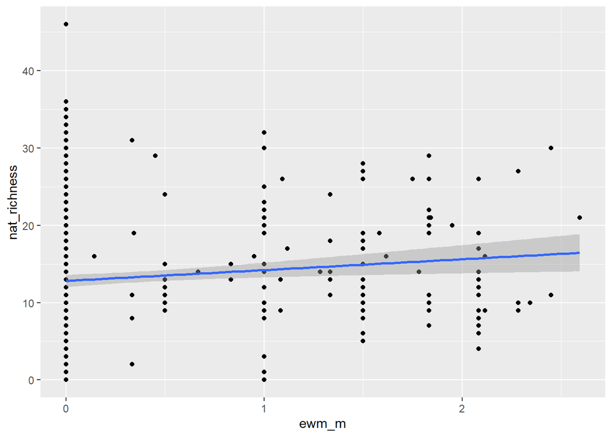

```r
ggplot(surveys[Myriophyllum_spicatum>0 & yday(DATESURVEYSTART)>151], aes(ewm_m, nat_richness ) ,)+
  geom_point()+ geom_smooth(method = "lm")
```

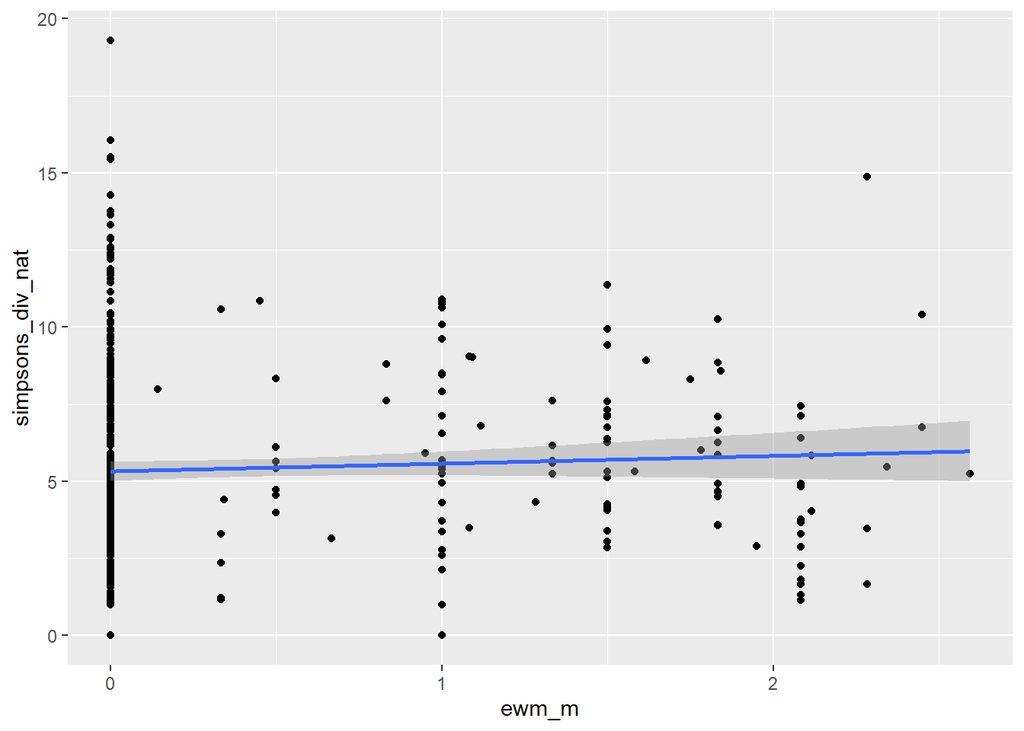

```r
ggplot(surveys[Myriophyllum_spicatum>0 & yday(DATESURVEYSTART)>151], aes(ewm_m, simpsons_div_nat ) ,)+
  geom_point()+ geom_smooth(method = "lm")
```

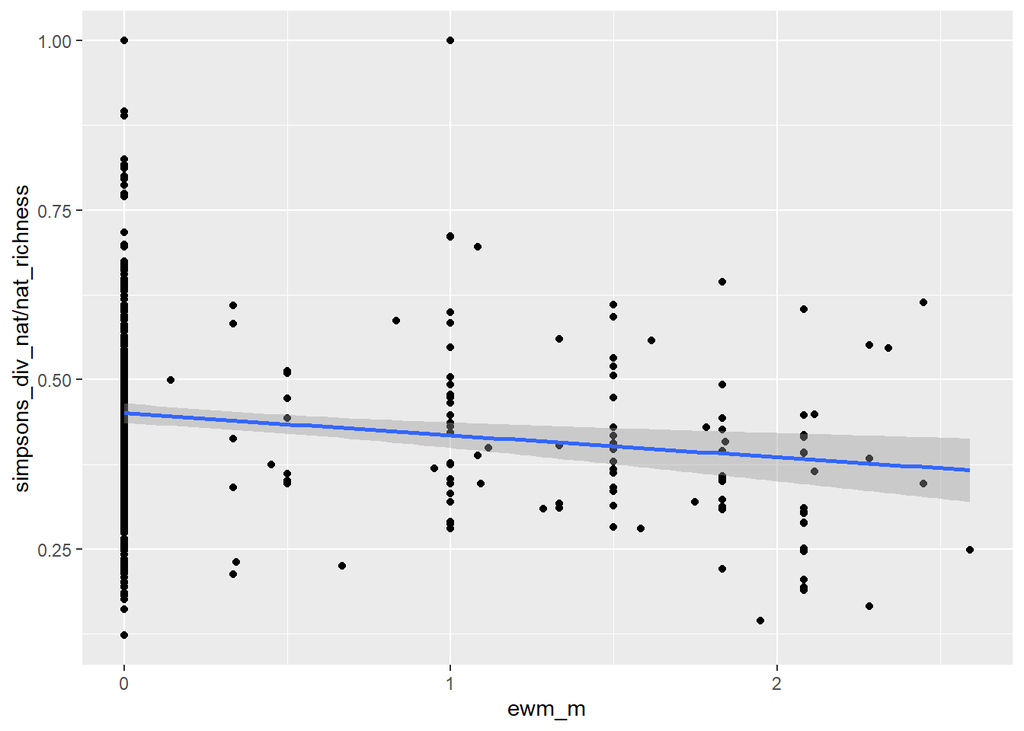

```r
ggplot(surveys[Myriophyllum_spicatum>0 & yday(DATESURVEYSTART)>151], aes(ewm_m, simpsons_div_nat/nat_richness ) ,)+
  geom_point()+ geom_smooth(method = "lm")
```

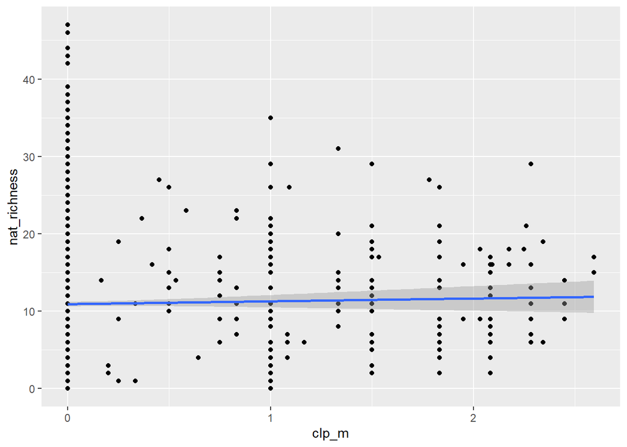

```r
ggplot(surveys[yday(DATESURVEYSTART)>151], aes(clp_m, nat_richness ) ,)+
  geom_point()+ geom_smooth(method = "lm")
```

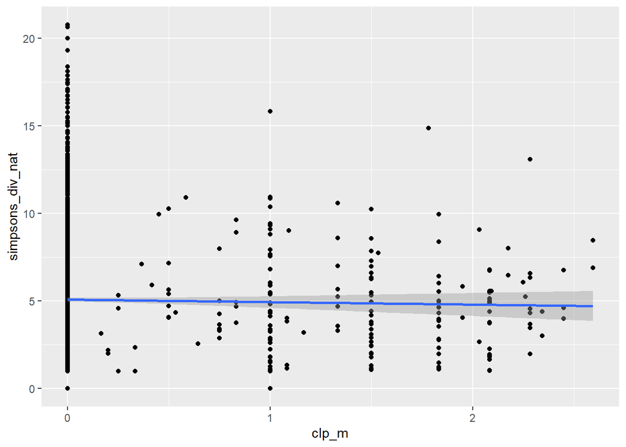

```r
ggplot(surveys[yday(DATESURVEYSTART)>151], aes(clp_m, simpsons_div_nat ) ,)+
  geom_point()+ geom_smooth(method = "lm")
```

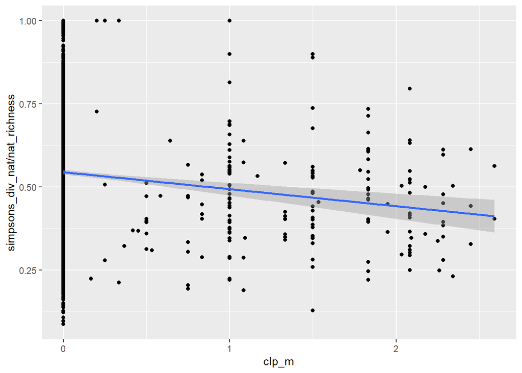

```r
ggplot(surveys[yday(DATESURVEYSTART)>151], aes(clp_m, simpsons_div_nat/nat_richness ) ,)+
  geom_point()+ geom_smooth(method = "lm")
```

we can also take a simpler look at a within yr effect separated from previous treatment effects:

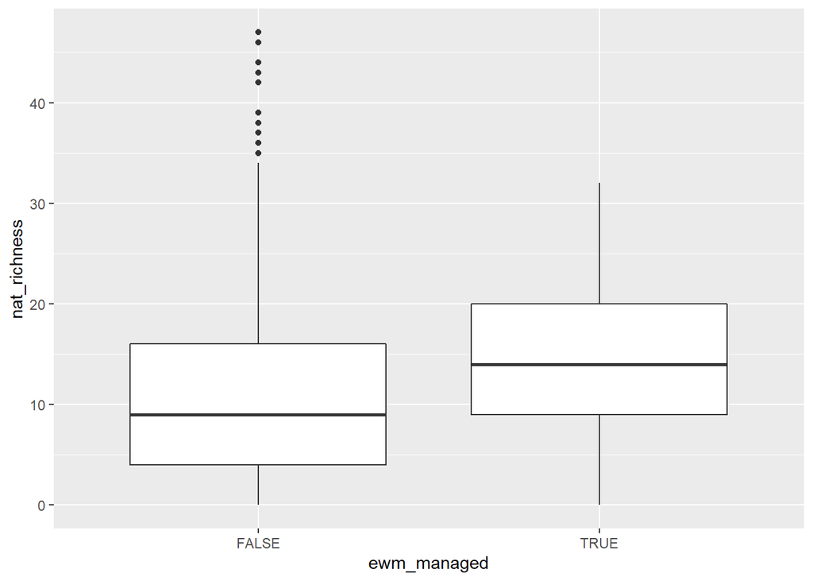

```r
ggplot(surveys[yday(DATESURVEYSTART) > 151], aes(ewm_managed, nat_richness ) ,)+
  geom_boxplot()
```

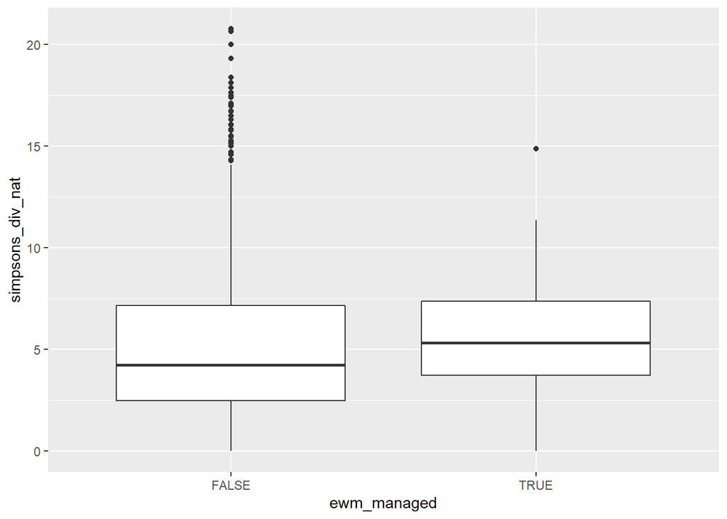

```r
ggplot(surveys[yday(DATESURVEYSTART) > 151], aes(ewm_managed, simpsons_div_nat ) ,)+
  geom_boxplot()
```

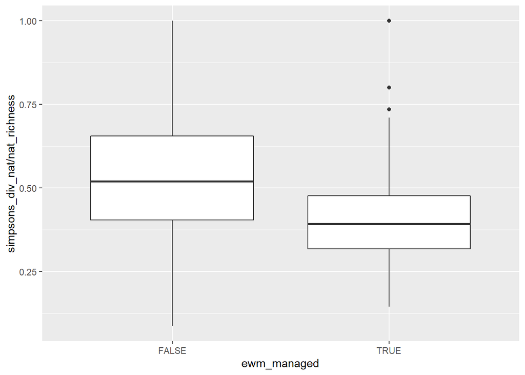

```r
ggplot(surveys[yday(DATESURVEYSTART) > 151], aes(ewm_managed, simpsons_div_nat/nat_richness ) ,)+
  geom_boxplot()
```

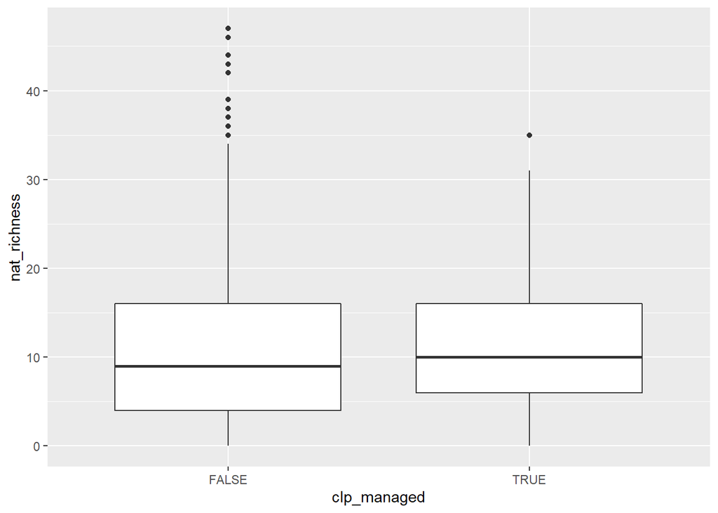

```r
ggplot(surveys[yday(DATESURVEYSTART) > 151], aes(clp_managed, nat_richness ) ,)+
  geom_boxplot()
```

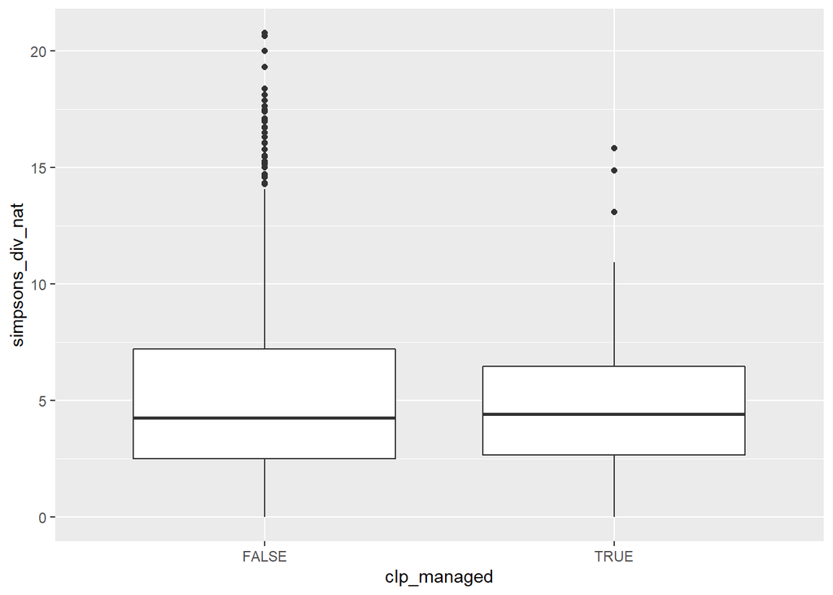

```r
ggplot(surveys[yday(DATESURVEYSTART) > 151], aes(clp_managed, simpsons_div_nat ) ,)+
  geom_boxplot()
```

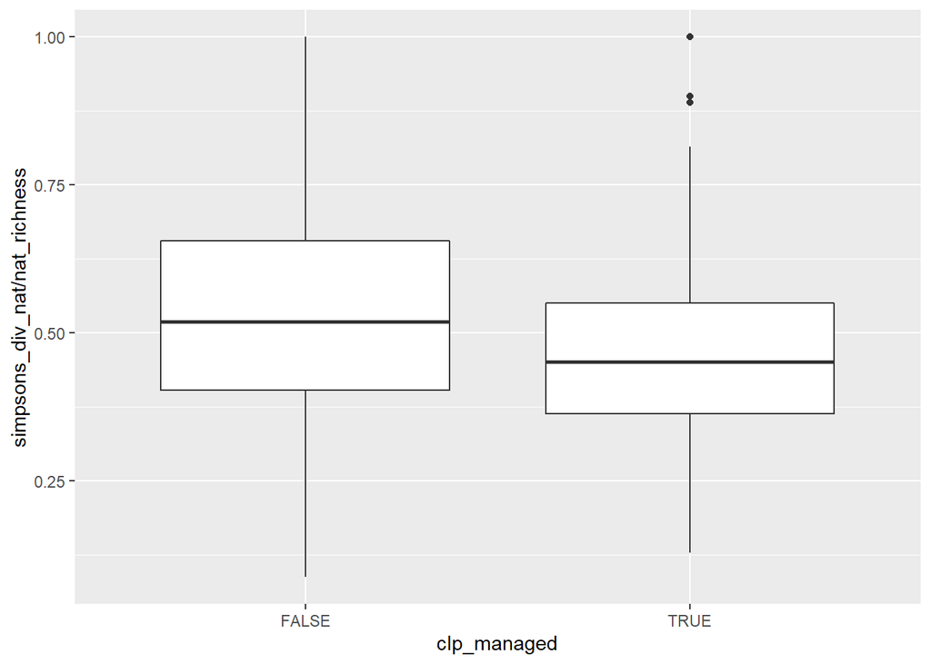

```r
ggplot(surveys[yday(DATESURVEYSTART) > 151], aes(clp_managed, simpsons_div_nat/nat_richness ) ,)+
  geom_boxplot()
```

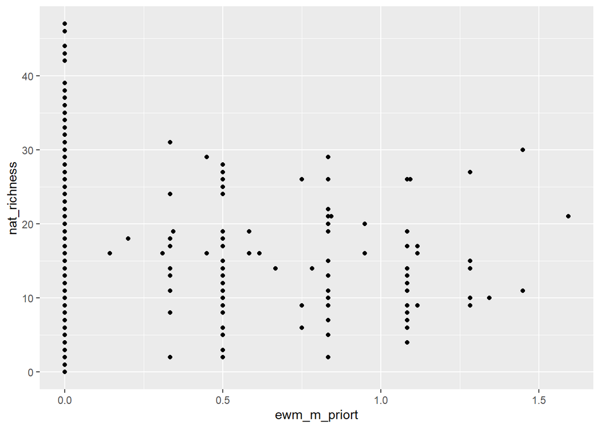

```r
ggplot(surveys[yday(DATESURVEYSTART) > 151, ], aes(ewm_m_priort, nat_richness ) ,)+
  geom_point()
```

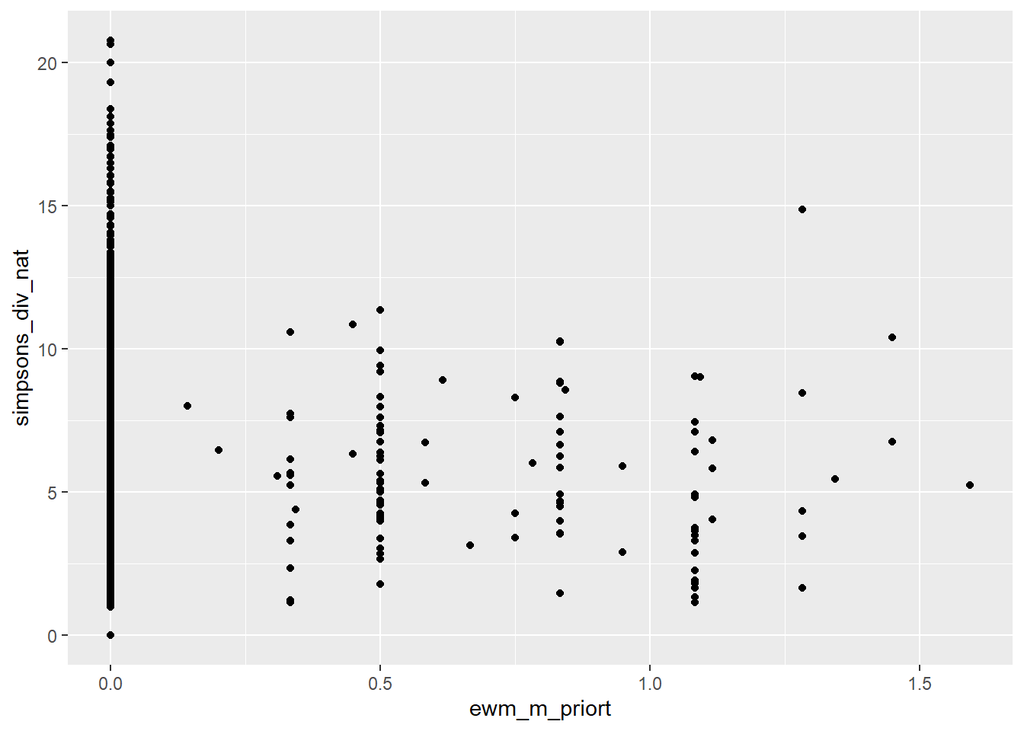

```r
ggplot(surveys[yday(DATESURVEYSTART) > 151], aes(ewm_m_priort, simpsons_div_nat ) ,)+
  geom_point()
```

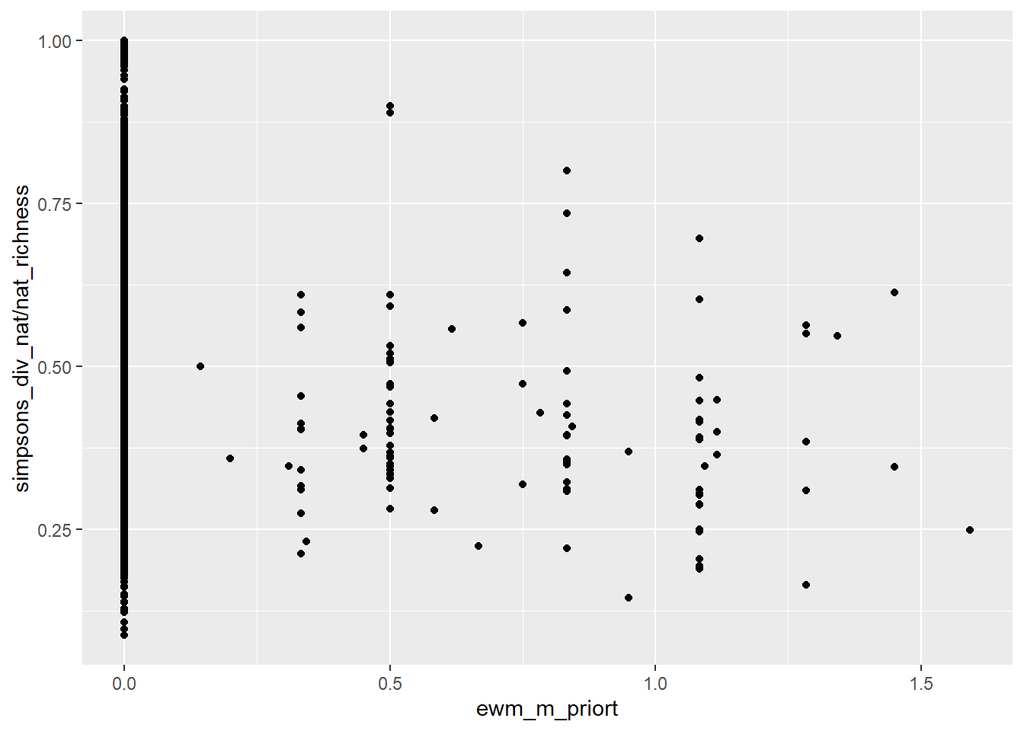

```r
ggplot(surveys[yday(DATESURVEYSTART) > 151], aes(ewm_m_priort, simpsons_div_nat/nat_richness ) ,)+
  geom_point()
```